# Table of Contents

```python
import random
```

## Introduction

- **Probability** is the branch of mathematics concerned with experiments whose outcomes we are **not certain** about
- The probability of an **event** expresses how likely it is to occur. It is a number **between 0 and 1**
- The probability of an event $A$ is written as $P(A)$
- $P(A)=0$ means the event is impossible
- $P(A)=1$ means the event is certain
- The **sample space** $\Omega$ of an experiment is the **set** of possible outcomes
- An event is a subset of the sample space
- **Simulations** can be done to guess probability values: the relative frequency tends to the theoretical probability

**Example experiment**: flipping one coin

[figure not shown]

The sample space is $\Omega = \{H, T\}$, head and tails

$P(H) = \frac{1}{2} (=0.5 = 50\%)$

$P(T) = \frac{1}{2}$

Lets simulate this

```python
sample_space = ["H", "T"]
```

```python
# run experiment 10 times
flips = random.choices(sample_space, k=10)
flips
```

```
['T', 'T', 'T', 'H', 'H', 'T', 'T', 'T', 'T', 'H']
```

```python
frequency_H = flips.count("H") / len(flips)
frequency_H
```

```
0.3
```

```python
# run experiment 100000 times
flips = random.choices(sample_space, k=100000)
```

```python
frequency_H = flips.count("H") / len(flips)
frequency_H
```

```
0.50164
```

**Example experiment**: flipping two coins

[figure not shown]

The sample space is $\Omega = \{HH, HT, TH, TT\}$

$P(\text{two heads}) = \frac{1}{4}$

$P(\text{two tails}) = \frac{1}{4}$

**Example experiment**: rolling a die

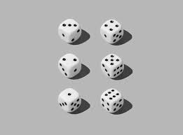

The sample space is $\Omega = \{1, 2, 3, 4, 5, 6\}$

$P(1) = \frac{1}{6}$

$P(4) = \frac{1}{6} \sim 0.16$

$P(7) = 0$

```python
sample_space = [1, 2, 3, 4, 5, 6]
```

```python
# run experiment 10 times
rolls = random.choices(sample_space, k=10)
rolls
```

```
[5, 5, 4, 5, 1, 5, 2, 4, 5, 5]
```

```python
frequency_fours = rolls.count(4) / len(rolls)
frequency_fours
```

```
0.2
```

```python
# run experiment 1000 times
rolls = random.choices(sample_space, k=1000)
```

```python
frequency_fours = rolls.count(4) / len(rolls)
frequency_fours
```

```
0.162
```

## Laplace Rule

(Intuitive)

If every outcome in $\Omega$ occurs with the same probability then the probability of any event is simply

$P(event)=\frac {\text{number of outcomes in event}}{\text{number of outcomes in sample space}}$

**Example experiment**: flipping two coins

[figure not shown]

The sample space is $\Omega = \{HH, HT, TH, TT\}$

$P(\text{one of each}) = \frac{2}{4}$

$P(\text{both the same}) = \frac{2}{4}$

**Example experiment**: rolling a die

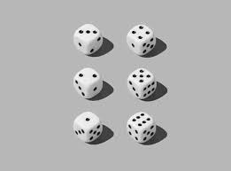

The sample space is $\Omega = \{1, 2, 3, 4, 5, 6\}$

$P(\text{odd}) = \frac{3}{6}$

$P(\text{bigger than 4}) = \frac{2}{6}$

**Example experiment**: draw a ball from the bag

$\Omega = \{B, B, B, R, R, R, R, R, R, R, G, G, G, G, G, G, G, G, G, G\}$

3 blue, 7 red, 10 green

$P(red)=\frac{7}{20}$

$P(blue)=\frac{3}{20}$

**Example experiment**: 3 letter words with letters A, B, C, once each

$\Omega = \{ABC, ACB, BAC, BCA, CAB, CBA\}$

$P(\text{starts with A})=\frac{2}{6}$

$P(\text{contains an A})=\frac{6}{6}=1=100\%$

**Example experiment**: what is the probability of winning the lottery. Numbers 00000 to 99999

## Compound events

### Union, intersection

$A$ and $B$ are events

$A \cap B$ (A intersection B) is another event, that happens if **both** $A$ and $B$ happen

$A \cup B$ (A union B) is another event, that happens if **any** of $A$, $B$ happens

[figure not shown]

**Example experiment**: draw one card from the deck

[figure not shown]

$P(king)=\frac{4}{40}$

$P(oro)=\frac{10}{40}$

$P(king \cap oro)=\frac{1}{40}$

$P(king \cup oro)=\frac{13}{40}$

$$P(A \cup B)=P(A)+P(B)-P(A \cap B)$$

### Opposite

$A$ is an event

$\overline{A}$ is the opposite event

$P(\text{no oro})=\frac{30}{40}$

$P(\text{oro})=\frac{10}{40}$

$$P(\overline{A}) = 1-P(A)$$

## Conditional probability

### Intiuition

$P(A|B)$ is the probability of $A$ happening, knowing that $B$ happened

[figure not shown]

Give approximate answers:

- What is the probability of a cat being a female?
- What is the probability of a cat being a female and 3 coloured?
- Given that a cat is female, what is the probability of it being 3 coloured?
- Given that a cat is 3 coloured, what is the probability of it being female?

$P(\text{female}) \sim \frac{1}{2}$

$P(\text{3coloured} \cap \text{female}) \sim \frac{1}{8}$

$P(\text{3coloured} | \text{female}) \sim \frac{1}{4}$

$P(\text{female} | \text{3coloured}) \sim 0.95$

### Formal definition

$$P(A|B)=\frac{P(A \cap B)}{P(B)}$$

$P(\text{3coloured} | \text{female})=\frac{P(\text{3coloured} \cap \text{female})}{P(\text{female})}$

### Misleading examples

Pfizer just announced 90% efficiency of COVID-19 vaccine

This should mean $P(\text{infection} | \text{vaccine}) = 0.10$

[Article regarding Pfizer vaccine](https://www.xataka.com/medicina-y-salud/pfizer-dice-que-su-vacuna-covid-19-tiene-eficacia-90-primeros-datos-estudio-fase-iii-que-esta-marcha)

After reading the article, we see that what really happened is:  
$P(\text{vaccine}|\text{infection})=0.10$

"99% of three coloured cats are female"  
**is not the same as**  
"99% of female cats are three coloured"

## Compound events cont.

### Independent events

If several events are independent, the probability of them ocurring **all** is the product of their probabilities

$A$, $B$ independent $\Rightarrow$ $P(A \cap B)=P(A) * P(B)$

**Exercise**: What is the probability of rolling three dice and getting three fives?

$P(\text{three fives})=\frac{1}{6}*\frac{1}{6}*\frac{1}{6}=\frac{1}{216}$

**Exercise**: We draw a card from the deck and put it back. We draw again a card. What is the probability of having drawn two Aces?

$P(\text{two Aces})=\frac{1}{10}*\frac{1}{10}=\frac{1}{100}$

### Dependent events

If several events are dependent, the probability of them ocurring all is **not** the product of their probabilities

$A$, $B$ dependent $\Rightarrow$ $P(A \cap B)=P(A) * P(B|A)$

$P(\text{two Aces})=\frac{1}{10}*\frac{3}{39}=\frac{1}{130}$

## Summary

- Probability lets us model uncertain experiments
- Laplace rule lets us compute probability when we know the sample space and all events are equally possible
- Compound events' probability might be computed from a series of multiplications, being aware of event dependance

The main techniques used to solve probability problems are:

- Laplace: favorable / total
- Union: $P(A \cup B)=P(A)+P(B)-P(A \cap B)$
- Intersection/multiplication: $P(A \cap B)=P(A) * P(B|A)$

## Challenges

- 3 coins are tossed: what is the probability of 3 heads? (Multiplication)
- 3 coins are tossed: what is the probability of 2 heads? (Laplace)
- You have 6 blue marbles, 3 red marbles, and 5 yellow marbles in a bag. What is the probability of selecting a blue marble on the first draw? (Laplace)
- You have 6 blue marbles, 3 red marbles, and 5 yellow marbles in a bag. What is the probability of selecting a blue marble or red marble on the first draw? (Laplace, Union)
- You have 6 blue marbles, 3 red marbles, and 5 yellow marbles in a bag. You draw 2 balls with replacement. What is the probability of 2 blues? (Multiplication)
- You have 6 blue marbles, 3 red marbles, and 5 yellow marbles in a bag. You draw 2 balls without replacement. What is the probability of 2 blues? (Multiplication)
- You roll 2 dice. What is the probability that the sum of the numbers is 7? And 8? And 9? Then simulate 10000 times and draw a histogram.